# Feather River - Hypothesis Models vs. Mixed Models for Fish Occurrence

Maddee Wiggins (FlowWest)

2026-10-20

**DRAFT.** This document compares two ways of modeling fish presence/absence in the Feather River mini snorkel data, on identical data:

1. **Hypothesis models** (feather_river_hypothesis_models.Rmd): a pre-specified set of GLMs with fixed effects only, compared with AICc.
2. **Mixed model** (feather_river_cover_analysis_salmon_ha_cover.Rmd): one model with the habitat terms and random intercepts for site and month.

Species: chinook.

## Shared data

The code for the data preparation, combined HA cover, redd count and the hypothesis model set is read from the hypothesis Rmd (the named chunks are evaluated here), not copied. If it changes there, this comparison changes with it. They run silently here; see that document for their output.

````r
# Evaluate the named code chunks of the hypothesis Rmd in this document's
# environment. They are read from that file, not copied, so both approaches use
# the same data preparation and model definitions.
source_chunks <- function(rmd, labels, envir = knitr::knit_global()) {
  lines <- readLines(rmd, warn = FALSE)
  starts <- grep("^```\\{r", lines)
  fences <- grep("^```\\s*$", lines)
  chunk_label <- function(l) trimws(sub("^```\\{r[ ,]*([^,}]*).*$", "\\1", l))
  for (lab in labels) {
    s <- starts[vapply(lines[starts], chunk_label, "") == lab]
    if (length(s) != 1) stop("Chunk '", lab, "' not found exactly once in ", rmd)
    e <- fences[fences > s][1]
    eval(parse(text = lines[(s + 1):(e - 1)]), envir = envir)
  }
  invisible(labels)
}

source_chunks(
  here("mini-snorkel-analysis", "analysis", "feather_river_hypothesis_models.Rmd"),
  c("read-data", "survey-attrs", "unit-level", "coding", "cover-map", "cover-classify",
    "redd", "model-data", "specs", "helpers", "fit-main")
)
````

```r
tibble(rows = nrow(model_data),
       presences = sum(model_data$presence),
       absences = sum(model_data$presence == 0),
       sites = n_distinct(model_data$location),
       surveys = n_distinct(model_data$location_table_id)) |>
  knitr::kable(caption = "Rows used by every model below (complete cases, one row per microhabitat unit)")
```

Rows used by every model below (complete cases, one row per microhabitat unit)

| rows | presences | absences | sites | surveys |
| --- | --- | --- | --- | --- |
| 8415 | 223 | 8192 | 29 | 242 |

## The two approaches

|  | Hypothesis models | Mixed model |
| --- | --- | --- |
| Question | Which hypothesis (cover, depth, flow, combinations; then redd, season, design) is best supported? | What are the habitat effects after allowing baseline presence to differ by site and month? |
| Model set | 10 pre-specified GLMs, ranked by AICc | One model (plus nested variants), reported with effect sizes |
| Site and month | Hypotheses tested last (month and design added to the best habitat model) | Random intercepts in the model from the start |
| Habitat terms | Separate hypotheses: cover, depth, velocity, and combinations | All in one model: cover + depth + velocity + redd + turbidity |
| Strength | Directly tests competing explanations | Accounts for repeated sampling at sites and across months |

## Models fit

```r
model_data <- model_data |>
  mutate(redd_presence = as.integer(redd_total > 0))

habitat_terms <- c("cover", "depth_z", "velocity_z",
                   if (params$use_redd) c("redd_z", "redd_presence"),
                   "surface_turbidity_z")
habitat_rhs <- paste(habitat_terms, collapse = " + ")

re_loc      <- "(1 | location)"
re_nested   <- "(1 | channel_location/location)"
re_locmonth <- "(1 | location) + (1 | month)"

best_stage1 <- main$stage1_best
best_rhs <- main$rhs[[best_stage1]]

catalog <- bind_rows(
  tibble(approach = "Hypothesis (GLM)", model = names(main$rhs), rhs = unname(main$rhs),
         re = NA_character_),
  tibble(approach = "Mixed model",
         model = c("mixed_loc", "mixed_nested", "mixed_final"),
         rhs = habitat_rhs, re = c(re_loc, re_nested, re_locmonth)),
  tibble(approach = "Hybrid",
         model = "best_habitat_month_siteRE",
         rhs = add_term(best_rhs, "month"), re = re_loc),
  tibble(approach = "Baseline",
         model = c("month_only", "re_only"),
         rhs = c("month", "1"), re = c(NA_character_, re_locmonth))
)

fit_any <- function(rhs, re = NA_character_) {
  f <- as.formula(paste("presence ~", rhs, if (!is.na(re)) paste("+", re)))
  if (is.na(re)) glm(f, data = model_data, family = binomial(link = "logit"))
  else glmmTMB(f, data = model_data, family = binomial(link = "logit"))
}

catalog$fit <- map2(catalog$rhs, catalog$re, fit_any)

catalog |>
  transmute(approach, model, formula = paste("presence ~", rhs, ifelse(is.na(re), "", paste("+", re)))) |>
  mutate(formula = str_wrap(formula, 90)) |>
  knitr::kable(caption = "Models compared. `best_habitat_month_siteRE` = best stage 1 habitat model + month (fixed) + (1 | location). Baselines: month alone, and site + month random effects with no habitat.")
```

Models compared. `best_habitat_month_siteRE` = best stage 1 habitat model + month (fixed) + (1 | location). Baselines: month alone, and site + month random effects with no habitat.

| approach | model | formula |
| --- | --- | --- |
| Hypothesis (GLM) | null | presence ~ 1 |
| Hypothesis (GLM) | cover | presence ~ cover |
| Hypothesis (GLM) | cover_turb | presence ~ cover + surface_turbidity_z |
| Hypothesis (GLM) | depth | presence ~ depth_z |
| Hypothesis (GLM) | flow | presence ~ velocity_z |
| Hypothesis (GLM) | dcv | presence ~ depth_z + velocity_z + cover |
| Hypothesis (GLM) | dcv_turb | presence ~ depth_z + velocity_z + cover + surface_turbidity_z |
| Hypothesis (GLM) | best_redd | presence ~ depth_z + velocity_z + cover + redd_z |
| Hypothesis (GLM) | best_season | presence ~ depth_z + velocity_z + cover + month |
| Hypothesis (GLM) | best_design | presence ~ depth_z + velocity_z + cover + channel_location + channel_geomorphic_unit + |
| number_of_divers |  |  |
| Mixed model | mixed_loc | presence ~ cover + depth_z + velocity_z + redd_z + redd_presence + surface_turbidity_z + |
| (1 \| location) |  |  |
| Mixed model | mixed_nested | presence ~ cover + depth_z + velocity_z + redd_z + redd_presence + surface_turbidity_z + |
| (1 \| channel_location/location) |  |  |
| Mixed model | mixed_final | presence ~ cover + depth_z + velocity_z + redd_z + redd_presence + surface_turbidity_z + |
| (1 \| location) + (1 \| month) |  |  |
| Hybrid | best_habitat_month_siteRE | presence ~ depth_z + velocity_z + cover + month + (1 \| location) |
| Baseline | month_only | presence ~ month |
| Baseline | re_only | presence ~ 1 + (1 \| location) + (1 \| month) |

The mixed-model formula is the one used in the HA cover Rmd, except that continuous predictors are standardized here (which does not change AICc or AUC). `best_stage1` in the hypothesis set is dcv.

## Comparison on identical rows

```r
aicc_of <- function(m) {
  k <- as.integer(attr(logLik(m), "df")); n <- nobs(m)
  -2 * as.numeric(logLik(m)) + 2 * k + 2 * k * (k + 1) / (n - k - 1)
}

# Nakagawa-style R2 for binomial-logit models:
# marginal = fixed effects only; conditional = fixed + random effects
r2_logit <- function(m) {
  is_mixed <- inherits(m, "glmmTMB")
  link_fixed <- if (is_mixed) predict(m, type = "link", re.form = NA) else predict(m, type = "link")
  var_f <- var(as.numeric(link_fixed))
  var_re <- if (is_mixed) sum(vapply(VarCorr(m)$cond, function(v) as.numeric(v[1, 1]), numeric(1))) else 0
  var_e <- pi^2 / 3
  tibble(r2_marginal = var_f / (var_f + var_re + var_e),
         r2_conditional = (var_f + var_re) / (var_f + var_re + var_e))
}

metrics <- catalog |>
  mutate(
    k = map_int(fit, ~ as.integer(attr(logLik(.x), "df"))),
    AICc = map_dbl(fit, aicc_of),
    auc_in_sample = map_dbl(fit, ~ as.numeric(pROC::auc(pROC::roc(model_data$presence,
                                  as.numeric(predict(.x, type = "response")),
                                  levels = c(0, 1), direction = "<", quiet = TRUE)))),
    r2 = map(fit, r2_logit)
  ) |>
  unnest(r2) |>
  mutate(delta_AICc = AICc - min(AICc))
```

### Cross-validated prediction

In-sample AUC rewards model size and site-specific intercepts. Leave-one-site-out cross-validation refits each model without one site and predicts that site’s units. Mixed models predict a new site with its random intercept set to zero but keep the month effects (months are shared across sites). Log loss is the mean negative log-likelihood of held-out units (lower is better).

```r
cv_loso <- function(rhs, re = NA_character_, data = model_data, group = "location") {
  f <- as.formula(paste("presence ~", rhs, if (!is.na(re)) paste("+", re)))
  pred <- rep(NA_real_, nrow(data))
  for (g in unique(data[[group]])) {
    test <- data[[group]] == g
    pred[test] <- tryCatch({
      if (is.na(re)) {
        m <- suppressWarnings(glm(f, data = data[!test, ], family = binomial))
        as.numeric(predict(m, newdata = data[test, ], type = "response"))
      } else {
        m <- suppressWarnings(glmmTMB(f, data = data[!test, ], family = binomial))
        as.numeric(predict(m, newdata = data[test, ], type = "response", allow.new.levels = TRUE))
      }
    }, error = function(e) rep(NA_real_, sum(test)))
  }
  ok <- !is.na(pred)
  eps <- 1e-6
  p <- pmin(pmax(pred[ok], eps), 1 - eps)
  y <- data$presence[ok]
  tibble(n_scored = sum(ok),
         auc_loso = as.numeric(pROC::auc(pROC::roc(y, pred[ok], levels = c(0, 1), direction = "<", quiet = TRUE))),
         logloss_loso = -mean(y * log(p) + (1 - y) * log(1 - p)))
}

cv_models <- c("null", best_stage1, "best_season", "best_design", "best_redd",
               "mixed_loc", "mixed_final", "best_habitat_month_siteRE", "month_only", "re_only")

if (params$cv_models) {
  cv_tab <- catalog |>
    filter(model %in% cv_models) |>
    mutate(cv = map2(rhs, re, cv_loso)) |>
    select(model, cv) |>
    unnest(cv)
  metrics <- metrics |> left_join(cv_tab, by = "model")
} else {
  metrics <- metrics |> mutate(n_scored = NA_integer_, auc_loso = NA_real_, logloss_loso = NA_real_)
}
```

```r
metrics |>
  arrange(AICc) |>
  select(approach, model, k, AICc, delta_AICc, auc_in_sample, auc_loso, logloss_loso,
         r2_marginal, r2_conditional) |>
  mutate(across(c(AICc, delta_AICc), ~ round(.x, 1)),
         across(c(auc_in_sample, auc_loso, r2_marginal, r2_conditional), ~ round(.x, 3)),
         logloss_loso = round(logloss_loso, 4)) |>
  knitr::kable(caption = "All models on identical rows, ordered by AICc. R2 is marginal (fixed effects) and conditional (fixed + random). Leave-one-site-out columns are blank for models not cross-validated.")
```

All models on identical rows, ordered by AICc. R2 is marginal (fixed effects) and conditional (fixed + random). Leave-one-site-out columns are blank for models not cross-validated.

| approach | model | k | AICc | delta_AICc | auc_in_sample | auc_loso | logloss_loso | r2_marginal | r2_conditional |
| --- | --- | --- | --- | --- | --- | --- | --- | --- | --- |
| Hybrid | best_habitat_month_siteRE | 10 | 1635.3 | 0.0 | 0.888 | 0.782 | 0.1147 | 0.393 | 0.543 |
| Mixed model | mixed_final | 9 | 1642.1 | 6.7 | 0.889 | 0.830 | 0.1067 | 0.110 | 0.532 |
| Baseline | re_only | 3 | 1704.6 | 69.3 | 0.874 | 0.750 | 0.1118 | 0.000 | 0.509 |
| Hypothesis (GLM) | best_season | 9 | 1783.2 | 147.9 | 0.815 | 0.775 | 0.1128 | 0.441 | 0.441 |
| Baseline | month_only | 6 | 1817.4 | 182.1 | 0.786 | 0.737 | 0.1136 | 0.428 | 0.428 |
| Mixed model | mixed_loc | 8 | 1863.9 | 228.6 | 0.790 | 0.704 | 0.1189 | 0.164 | 0.249 |
| Mixed model | mixed_nested | 9 | 1865.9 | 230.6 | 0.790 | NA | NA | 0.164 | 0.249 |
| Hypothesis (GLM) | best_redd | 5 | 1906.3 | 271.0 | 0.736 | 0.698 | 0.1194 | 0.123 | 0.123 |
| Hypothesis (GLM) | best_design | 13 | 1911.0 | 275.7 | 0.754 | 0.688 | 0.1195 | 0.698 | 0.698 |
| Hypothesis (GLM) | dcv | 4 | 2019.0 | 383.7 | 0.641 | 0.542 | 0.1231 | 0.051 | 0.051 |
| Hypothesis (GLM) | dcv_turb | 5 | 2020.9 | 385.6 | 0.639 | NA | NA | 0.051 | 0.051 |
| Hypothesis (GLM) | depth | 2 | 2035.5 | 400.2 | 0.606 | NA | NA | 0.024 | 0.024 |
| Hypothesis (GLM) | cover | 2 | 2046.7 | 411.4 | 0.569 | NA | NA | 0.023 | 0.023 |
| Hypothesis (GLM) | cover_turb | 3 | 2048.5 | 413.2 | 0.585 | NA | NA | 0.023 | 0.023 |
| Hypothesis (GLM) | null | 1 | 2061.3 | 426.0 | 0.500 | 0.258 | 0.1240 | 0.000 | 0.000 |
| Hypothesis (GLM) | flow | 2 | 2063.3 | 428.0 | 0.549 | NA | NA | 0.000 | 0.000 |

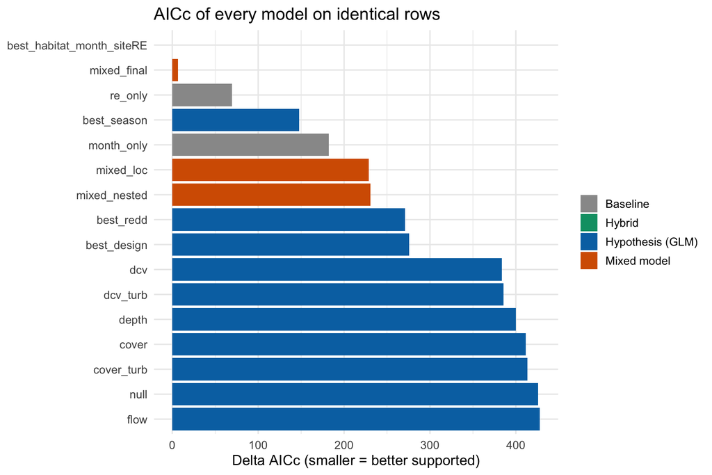

```r
metrics |>
  mutate(model = fct_reorder(model, -delta_AICc)) |>
  ggplot(aes(delta_AICc, model, fill = approach)) +
  geom_col() +
  scale_fill_manual(values = c("Hypothesis (GLM)" = "#0072B2", "Mixed model" = "#D55E00",
                               "Hybrid" = "#009E73", "Baseline" = "grey60"), name = NULL) +
  labs(x = "Delta AICc (smaller = better supported)", y = NULL,
       title = "AICc of every model on identical rows")
```

AICc compares the GLMs and mixed models on the same likelihood scale because the data and response are identical. The variance parameters of random effects are on a boundary, so treat small AICc differences between a GLM and a mixed model cautiously.

## What do site and month contribute?

This separates how much of the fit comes from the habitat hypotheses and how much from the site and month structure. Each row asks how much a habitat model improves on a model that already includes the named control, measured as AICc improvement (positive = habitat helps) and change in in-sample AUC.

```r
get <- function(model, col) metrics[[col]][metrics$model == model]

habitat_added <- tribble(
  ~control,                                ~without_habitat,  ~with_habitat,
  "none (intercept only)",                 "null",            best_stage1,
  "month (fixed effect)",                  "month_only",      "best_season",
  "site + month (random effects)",         "re_only",         "mixed_final"
) |>
  mutate(
    dAICc_gain = map2_dbl(without_habitat, with_habitat, ~ get(.x, "AICc") - get(.y, "AICc")),
    auc_without = map_dbl(without_habitat, ~ get(.x, "auc_in_sample")),
    auc_with = map_dbl(with_habitat, ~ get(.x, "auc_in_sample")),
    auc_gain = auc_with - auc_without
  ) |>
  mutate(across(c(dAICc_gain), ~ round(.x, 1)),
         across(c(auc_without, auc_with, auc_gain), ~ round(.x, 3)))

knitr::kable(habitat_added,
             caption = "Gain from habitat terms given each control (habitat model: best stage 1 for the first two rows, full mixed-model habitat terms for the last)")
```

Gain from habitat terms given each control (habitat model: best stage 1 for the first two rows, full mixed-model habitat terms for the last)

| control | without_habitat | with_habitat | dAICc_gain | auc_without | auc_with | auc_gain |
| --- | --- | --- | --- | --- | --- | --- |
| none (intercept only) | null | dcv | 42.3 | 0.500 | 0.641 | 0.141 |
| month (fixed effect) | month_only | best_season | 34.3 | 0.786 | 0.815 | 0.030 |
| site + month (random effects) | re_only | mixed_final | 62.6 | 0.874 | 0.889 | 0.015 |

The table below shows how much of the fitted structure is attributed to site and month rather than habitat.

```r
metrics |>
  filter(model %in% c("null", best_stage1, "month_only", "best_season", "re_only",
                      "mixed_loc", "mixed_final")) |>
  transmute(model,
            r2_marginal = round(r2_marginal, 3),
            r2_conditional = round(r2_conditional, 3),
            auc_in_sample = round(auc_in_sample, 3)) |>
  knitr::kable(caption = "Marginal R2 = variance explained by fixed effects; conditional R2 adds site and month random effects")
```

Marginal R2 = variance explained by fixed effects; conditional R2 adds site and month random effects

| model | r2_marginal | r2_conditional | auc_in_sample |
| --- | --- | --- | --- |
| null | 0.000 | 0.000 | 0.500 |
| dcv | 0.051 | 0.051 | 0.641 |
| best_season | 0.441 | 0.441 | 0.815 |
| mixed_loc | 0.164 | 0.249 | 0.790 |
| mixed_final | 0.110 | 0.532 | 0.889 |
| month_only | 0.428 | 0.428 | 0.786 |
| re_only | 0.000 | 0.509 | 0.874 |

## Do the conclusions about habitat agree?

### Hypothesis rankings with and without site and month random effects

```r
stage1_models <- main$table |> filter(stage == 1)
specs_used <- specs_main

stage1_re <- map_dfr(seq_len(nrow(specs_used)), function(i) {
  m <- fit_any(specs_used$rhs[i], re_locmonth)
  tibble(model = specs_used$model[i], AICc_re = aicc_of(m))
})

stage1_compare <- stage1_models |>
  select(model, AICc_glm = AICc) |>
  left_join(stage1_re, by = "model") |>
  mutate(
    gain_over_null_glm = AICc_glm[model == "null"] - AICc_glm,
    gain_over_null_re = AICc_re[model == "null"] - AICc_re,
    rank_glm = rank(AICc_glm),
    rank_re = rank(AICc_re)
  ) |>
  arrange(rank_glm)

stage1_compare |>
  mutate(across(c(AICc_glm, AICc_re, gain_over_null_glm, gain_over_null_re), ~ round(.x, 1))) |>
  knitr::kable(caption = "Stage 1 hypotheses: fixed-effects GLM vs. with site and month random effects. Gain over null = AICc improvement over the intercept-only (or random-effects-only) model; positive = supported.")
```

Stage 1 hypotheses: fixed-effects GLM vs. with site and month random effects. Gain over null = AICc improvement over the intercept-only (or random-effects-only) model; positive = supported.

| model | AICc_glm | AICc_re | gain_over_null_glm | gain_over_null_re | rank_glm | rank_re |
| --- | --- | --- | --- | --- | --- | --- |
| dcv | 2019.0 | 1652.7 | 42.3 | 51.9 | 1 | 1 |
| dcv_turb | 2020.9 | 1654.7 | 40.4 | 49.9 | 2 | 2 |
| depth | 2035.5 | 1671.8 | 25.8 | 32.8 | 3 | 3 |
| cover | 2046.7 | 1699.7 | 14.6 | 4.9 | 4 | 5 |
| cover_turb | 2048.5 | 1700.7 | 12.8 | 4.0 | 5 | 6 |
| null | 2061.3 | 1704.6 | 0.0 | 0.0 | 6 | 7 |
| flow | 2063.3 | 1687.1 | -2.0 | 17.5 | 7 | 4 |

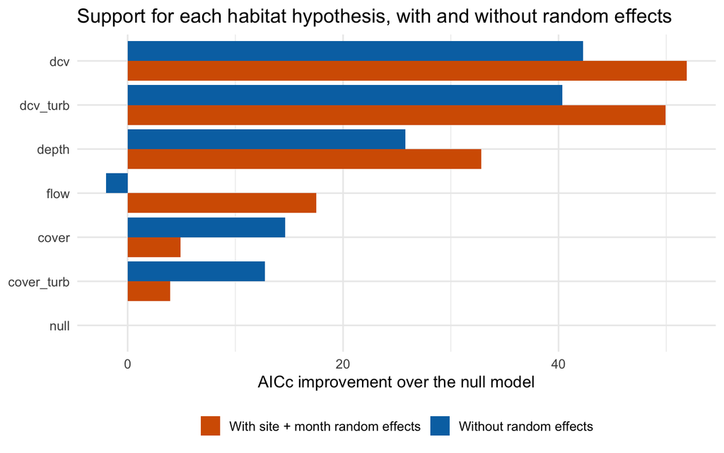

```r
stage1_compare |>
  select(model, `Without random effects` = gain_over_null_glm, `With site + month random effects` = gain_over_null_re) |>
  pivot_longer(-model, names_to = "fit", values_to = "gain") |>
  mutate(model = fct_reorder(model, gain, .fun = max)) |>
  ggplot(aes(gain, model, fill = fit)) +
  geom_col(position = "dodge") +
  scale_fill_manual(values = c("Without random effects" = "#0072B2",
                               "With site + month random effects" = "#D55E00"), name = NULL) +
  labs(x = "AICc improvement over the null model", y = NULL,
       title = "Support for each habitat hypothesis, with and without random effects") +
  theme(legend.position = "bottom")
```

### Effect sizes

Odds ratios for the habitat terms in the best stage 1 hypothesis model, the same model with month added, and the mixed model.

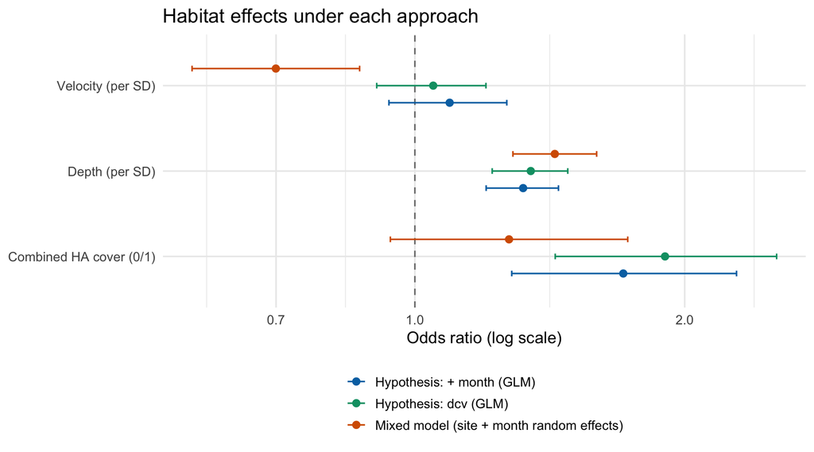

```r
tidy_any <- function(m, label) {
  out <- if (inherits(m, "glmmTMB")) broom.mixed::tidy(m, effects = "fixed", conf.int = TRUE)
         else broom::tidy(m, conf.int = TRUE)
  out |> mutate(fit = label)
}

pull_fit <- function(name) catalog$fit[[which(catalog$model == name)]]

effects_cmp <- bind_rows(
  tidy_any(pull_fit(best_stage1), paste0("Hypothesis: ", best_stage1, " (GLM)")),
  tidy_any(pull_fit("best_season"), "Hypothesis: + month (GLM)"),
  tidy_any(pull_fit("mixed_final"), "Mixed model (site + month random effects)")
) |>
  filter(term %in% c("cover", "depth_z", "velocity_z")) |>
  mutate(odds_ratio = exp(estimate), or_low = exp(conf.low), or_high = exp(conf.high),
         term = recode(term, cover = "Combined HA cover (0/1)",
                       depth_z = "Depth (per SD)", velocity_z = "Velocity (per SD)"))

ggplot(effects_cmp, aes(odds_ratio, term, color = fit)) +
  geom_vline(xintercept = 1, linetype = 2, color = "gray50") +
  geom_point(position = position_dodge(width = 0.6), size = 2.3) +
  geom_errorbarh(aes(xmin = or_low, xmax = or_high), height = 0.2,
                 position = position_dodge(width = 0.6)) +
  scale_x_log10() +
  scale_color_manual(values = c("#0072B2", "#009E73", "#D55E00"), name = NULL) +
  labs(x = "Odds ratio (log scale)", y = NULL,
       title = "Habitat effects under each approach") +
  theme(legend.position = "bottom", legend.direction = "vertical")
```

```r
effects_cmp |>
  transmute(fit, term, odds_ratio = round(odds_ratio, 2), or_low = round(or_low, 2),
            or_high = round(or_high, 2), p_value = signif(p.value, 2)) |>
  knitr::kable(caption = "Odds ratios for the shared habitat terms")
```

Odds ratios for the shared habitat terms

| fit | term | odds_ratio | or_low | or_high | p_value |
| --- | --- | --- | --- | --- | --- |
| Hypothesis: dcv (GLM) | Depth (per SD) | 1.35 | 1.22 | 1.48 | 0.0000000 |
| Hypothesis: dcv (GLM) | Velocity (per SD) | 1.05 | 0.91 | 1.20 | 0.5100000 |
| Hypothesis: dcv (GLM) | Combined HA cover (0/1) | 1.90 | 1.43 | 2.53 | 0.0000092 |
| Hypothesis: + month (GLM) | Depth (per SD) | 1.32 | 1.20 | 1.45 | 0.0000000 |
| Hypothesis: + month (GLM) | Velocity (per SD) | 1.09 | 0.94 | 1.27 | 0.2500000 |
| Hypothesis: + month (GLM) | Combined HA cover (0/1) | 1.71 | 1.28 | 2.28 | 0.0002700 |
| Mixed model (site + month random effects) | Combined HA cover (0/1) | 1.27 | 0.94 | 1.73 | 0.1200000 |
| Mixed model (site + month random effects) | Depth (per SD) | 1.43 | 1.29 | 1.60 | 0.0000000 |
| Mixed model (site + month random effects) | Velocity (per SD) | 0.70 | 0.56 | 0.87 | 0.0011000 |

### Variance among sites and months in the mixed model

```r
vc <- VarCorr(pull_fit("mixed_final"))$cond
tibble(group = names(vc),
       sd = vapply(vc, function(v) sqrt(as.numeric(v[1, 1])), numeric(1)),
       variance = vapply(vc, function(v) as.numeric(v[1, 1]), numeric(1))) |>
  mutate(across(c(sd, variance), ~ round(.x, 3))) |>
  knitr::kable(caption = "Random-intercept standard deviations (logit scale) in the final mixed model")
```

Random-intercept standard deviations (logit scale) in the final mixed model

| group | sd | variance |
| --- | --- | --- |
| location | 0.672 | 0.452 |
| month | 1.587 | 2.518 |

## Reading the comparison

- **Fit on identical rows:** the lowest AICc is best_habitat_month_siteRE (Hybrid). See the ordered table for the full ranking.
- **Habitat alone vs. with controls:** the best habitat hypothesis (dcv) has marginal R2 0.051 and in-sample AUC 0.641; the final mixed model has marginal R2 0.11, conditional R2 0.532 and in-sample AUC 0.889. The gap between marginal and conditional R2 is the part attributed to site and month rather than habitat.
- **Prediction at new sites:** use the leave-one-site-out columns (AUC and log loss), which do not reward site-specific intercepts the way in-sample AUC does.
- **Agreement on hypotheses:** compare the `rank_glm` and `rank_re` columns and the gains over null in the stage 1 table. If the same hypotheses stay on top, the two approaches agree on which habitat factors matter.
- **Effect sizes:** the plot shows whether the habitat odds ratios shift when month and site are modeled as random effects instead of tested as hypotheses.

## Caveats

- Both approaches use the same presence/absence data and the same combined HA cover definition; changing the cover threshold or rule in the hypothesis Rmd’s YAML parameters changes this comparison.
- Leave-one-site-out holds out entire sites but not entire months, so the month structure is seen in training.
- GLM and GLMM AICc values are comparable here because the data are identical, but random-effect variance parameters sit on a boundary, so small differences should not be over-interpreted.
- Pooled leave-one-site-out AUC is not 0.5 for a model with no site information. When a site is held out, an intercept-only model predicts the prevalence of the other sites, so the pooled predictions are partly anti-correlated with presence and the null’s pooled AUC is below 0.5. Compare models with log loss, and read AUC against the null model’s value rather than against 0.5.
- `best_design` has complete separation: no presences occur in some rare levels of channel geomorphic unit (for example backwater) or at some numbers of divers (for example four). Its coefficients and its R2 are unstable (standard errors in the hundreds), so do not interpret them. The AICc of that model should be read cautiously. Collapsing rare levels or treating divers as numeric would fix this in the hypothesis Rmd.
- Redd count is a site-level constant; in a model with a site random effect its effect is only weakly identified.
- Site, month and survey are not the only dependence in the data: units within a survey are also correlated. The hypothesis Rmd has a survey-level random intercept check; the mixed models here follow the HA cover Rmd (site and month).